# Covariate adjustments and baseline correction in clinical trials

## Covariate adjustments

Now we break the idillic scenario, because we introduce a covariate with huuuge reprecussions. if the covariate is 2 instead of 1, the observed value (eg. a change in a variable) increases 10x the treatment effect. Its independent of the treatment effect, since the treatment assignment is independent of everything (this is called randomization). The distribution of this covariate (or trait) is 50-50%.

Bottom line is that now the covariate is the main driver of the outcome, the treatment efect ‘hides’ in the data.

```r
sim_cov_study <- function(
    n_g = 5, eff = 10, eff_cov = 100, sd  = 3) {
  dat <- data.frame(
    arm = rep(1:2, each = n_g),
    cov = rep(1:2, n_g)
  )
  # reshuffling covariate
  dat$cov <- sample(dat$cov)
  dat$y <- 0 + eff * dat$arm + eff_cov * dat$cov + rnorm(nrow(dat), 0, sd)
  return(dat)
}

dat <- sim_cov_study()
```

Unsurprissingly the t-test is not significant.

```r
t.test(y ~ arm, data = dat)
```

```
##
##  Welch Two Sample t-test
##
## data:  y by arm
## t = -0.92158, df = 7.9727, p-value = 0.3838
## alternative hypothesis: true difference in means between group 1 and group 2 is not equal to 0
## 95 percent confidence interval:
##  -113.87751   48.87385
## sample estimates:
## mean in group 1 mean in group 2
##        149.9455        182.4473
```

Neither is the emmeans estimate.

```r
mod <- lm(y ~ arm, data = dat)

emmeans(mod, "arm")  %>%
  contrast("pairwise")
```

```
##  contrast    estimate   SE df t.ratio p.value
##  arm1 - arm2    -32.5 35.3  8  -0.922  0.3837
```

Lets say that we anticipated the covariate’s impact and we measured it and pre-defined it to be included in our model. The t-test is now quite persuasive for the same dataset.

```r
# fixing it
mod_cov <- lm(y ~ arm + cov, data = dat)

emmeans(mod_cov, "arm")  %>%
  contrast("pairwise")
```

```
##  contrast    estimate   SE df t.ratio p.value
##  arm1 - arm2    -12.2 1.59  7  -7.658  0.0001
##
## Results are averaged over the levels of: cov
```

Its simulation time! What would the distribution of the estimates look like after a bunch of simulations? We do the model either with or without the inclusion of the covariate.

```r
set.seed(999)

# Number of simulations
n_sim <- 100

# We'll hold results for each model in one combined data frame
p_cov_combined <- data.frame()

pb <- txtProgressBar(min = 0, max = n_sim, style = 3)
```

```
##   |                                                                              |                                                                      |   0%
```

```r
for(i in 1:n_sim) {
  dat <- sim_cov_study(n_g = 10, eff = 10)

  # Model without covariate
  mod_nocov <- lm(y ~ arm, data = dat)
  # Use emmeans to get pairwise contrast for 'arm'
  res_nocov <- emmeans(mod_nocov, "arm") %>%
    contrast("pairwise") %>%
    as.data.frame()
  # Label which model it is
  res_nocov$model <- "No covariate"
  res_nocov$rep <- i

  # Model with covariate
  mod_withcov <- lm(y ~ arm + cov, data = dat)
  res_withcov <- emmeans(mod_withcov, "arm") %>%
    contrast("pairwise") %>%
    as.data.frame()
  res_withcov$model <- "With covariate"
  res_withcov$rep <- i

  # Combine and store
  p_cov_combined <- rbind(p_cov_combined, res_nocov, res_withcov)

  setTxtProgressBar(pb, i)
}
```

```
##   |                                                                              |=                                                                     |   1%  |                                                                              |=                                                        …
```

```r
close(pb)
```

```r
# For plotting, compute the 95% CI for each contrast
p_cov_combined <- p_cov_combined %>%
  mutate(
    ci_low = estimate - 1.96 * SE,
    ci_upp = estimate + 1.96 * SE
  )
```

And that’s exactly what I hoped to show! Not taking the covariate into consideration results in estimates which - surely - are based on the distribution of the “2-covariated” subjects per arm (you can see the binomially distributed “clusters” in these naive estimates). However, despite the huuuuge effect of the covariate, we still could arrive at a reliable estimate of the treatment effect by including the covariate in the model.

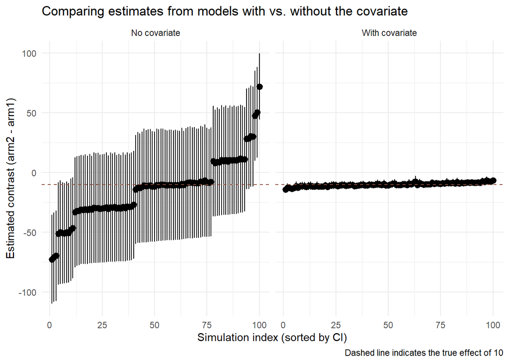

```r
# We can create a plot that facets by model
# One approach: sort by ci_low within each model to have a "nice" left-to-right ordering
p_cov_combined <- p_cov_combined %>%
  group_by(model) %>%
  arrange(ci_low, .by_group = TRUE) %>%
  mutate(id = row_number()) %>%
  ungroup()

fig_2 <-
  # Plot:
  ggplot(p_cov_combined, aes(x = id, y = estimate, ymin = ci_low, ymax = ci_upp)) +
  geom_pointrange() +
  facet_wrap(~ model, scales = "free_x") +
  geom_hline(yintercept = -10, linetype = "dashed",color="salmon4") +  # because true effect = 10
  theme_minimal() +
  labs(
    x = "Simulation index (sorted by CI)",
    y = "Estimated contrast (arm2 - arm1)",
    title = "Comparing estimates from models with vs. without the covariate",
    caption = "Dashed line indicates the true effect of 10"
  )
fig_2
```

## Baseline correction

Another of lifes mysteries is baseline correction. When searching for a treatment effect, we are most often searching for a *change* before and after treatment and then comparing this change to a different or no treatment. Easy enough, right?

Lets simulate both baseline and after treatment effects for two arms. These measurements would be correlated to each other somewhat, since they are taken from the same subject.

The package mvtnorm is used to simulate correlated, normally distributed data.

```r
sim_baseline_study <- function(
    n_g      = 5,       # number of subjects per arm
    eff      = 10,      # true difference for the follow-up measurement in arm 2 vs arm 1
    eff_corr = 0.5,     # correlation between baseline and follow-up
    sd       = 3
) {
  # Covariance matrix for the bivariate normal:
  # Variances = sd^2, Covariance = eff_corr * sd^2
  Sigma <- matrix(c(sd^2           , eff_corr * sd^2,
                    eff_corr * sd^2, sd^2),
                  nrow = 2)

  # List to store each arm's data
  all_data <- list()

  # Loop through arms
  for (arm_id in c(1, 2)) {
    # Define mean vector:
    # For baseline (meas = 1): always 0;
    # For follow-up (meas = 2): 0 in arm 1, eff in arm 2.
    mean_vec <- if (arm_id == 1) c(0, 0) else c(0, eff)

    # Simulate n_g subjects for this arm
    Y <- rmvnorm(n_g, mean = mean_vec, sigma = Sigma)

    # Create unique subject IDs (e.g., "1_1", "1_2", ... for arm 1)
    subject_id <- paste0(arm_id, "_", seq_len(n_g))

    # Build a wide-format data frame: 1 row per subject (baseline and follow-up)
    df_arm <- data.frame(
      id   = rep(subject_id, each = 1),
      arm  = rep(arm_id, each = 1 * n_g),
      y_before    = Y[,1],
      y_after     = Y[,2]
    )

    all_data[[arm_id]] <- df_arm
  }

  # Combine the data from both arms
  dat_wide <- do.call(rbind, all_data) %>%
    mutate(change = y_after - y_before,
           arm    = factor(arm, levels = c(1, 2), labels = c("arm1", "arm2")))


  return(dat_wide)
}

set.seed(42)
dat <- sim_baseline_study(n_g = 10, eff = 10, eff_corr = 0.6, sd = 3)
head(dat[sample(1:20),], 10)
```

|  | id | arm | y_before | y_after | change |
| --- | --- | --- | --- | --- | --- |
| 4 | 1_4 | arm1 | 4.2120656 | 1.16455133 | -3.0475142 |
| 13 | 2_3 | arm2 | 4.9854363 | 10.57280176 | 5.5873655 |
| 10 | 1_10 | arm1 | -5.6933212 | 1.44187823 | 7.1351994 |
| 9 | 1_9 | arm1 | -3.3291329 | -7.83007067 | -4.5009378 |
| 19 | 2_9 | arm2 | -3.0398513 | 6.83407137 | 9.8739227 |
| 12 | 2_2 | arm2 | 0.6630562 | 13.29392967 | 12.6308734 |
| 20 | 2_10 | arm2 | -6.8366865 | 7.81248827 | 14.6491748 |
| 17 | 2_7 | arm2 | 2.3682780 | 9.24895058 | 6.8806726 |
| 11 | 2_1 | arm2 | -2.5626063 | 4.63940441 | 7.2020107 |
| 3 | 1_3 | arm1 | 1.0498893 | 0.08148694 | -0.9684023 |

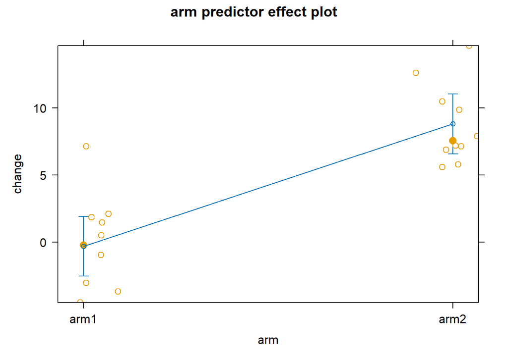

```r
# We can now fit a linear mixed model to this data
mod_simp <- lm(change ~ arm, data = dat)

mod_simp %>% effects::predictorEffects(partial.residuals = TRUE) %>% plot()
```

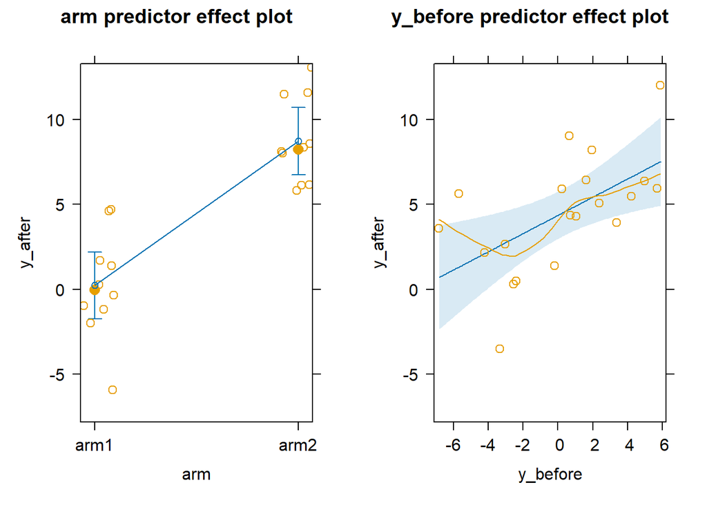

```r
# We can now fit a linear mixed model to this data
mod <- lm(y_after ~ arm + y_before, data = dat)

mod %>% effects::predictorEffects(partial.residuals = TRUE) %>% plot()
```

Aaaaand… it seems that the standard error of the baseline-corrected model is better!

```r
# emmeans stuff
emmeans(mod_simp, ~ arm) %>%
  contrast("pairwise")
```

```
##  contrast    estimate  SE df t.ratio p.value
##  arm1 - arm2    -9.12 1.5 18  -6.090  <.0001
```

```r
# emmeans stuff
emmeans(mod, ~ arm) %>%
  contrast("pairwise")
```

```
##  contrast    estimate   SE df t.ratio p.value
##  arm1 - arm2    -8.51 1.34 17  -6.363  <.0001
```

Again, lets see what the simulations turn up.

```r
# Let's do 100 simulations
set.seed(999)
n_sim <- 100

res_baseline <- data.frame()

pb <- txtProgressBar(min = 0, max = n_sim, style = 3)
```

```
##   |                                                                              |                                                                      |   0%
```

```r
for (i in 1:n_sim) {
  # Simulate the data
  dat <- sim_baseline_study(n_g = 5, eff = 10, eff_corr = 0.3, sd = 3)

  # Fit model without baseline correction
  mod_nobc <- lm(change ~ arm, data = dat)
  tmp_nobc <- emmeans(mod_nobc, ~ arm) %>%
    contrast("pairwise") %>%
    as.data.frame()
  tmp_nobc$model <- "No baseline correction"
  tmp_nobc$rep   <- i

  # Fit model with baseline correction
  mod_bc <- lm(y_after ~ arm + y_before, data = dat)
  tmp_bc <- emmeans(mod_bc, ~ arm) %>%
    contrast("pairwise") %>%
    as.data.frame()
  tmp_bc$model <- "With baseline correction"
  tmp_bc$rep   <- i

  # Combine
  res_baseline <- rbind(res_baseline, tmp_nobc, tmp_bc)

  setTxtProgressBar(pb, i)
}
```

```
##   |                                                                              |=                                                                     |   1%  |                                                                              |=                                                        …
```

```r
close(pb)
```

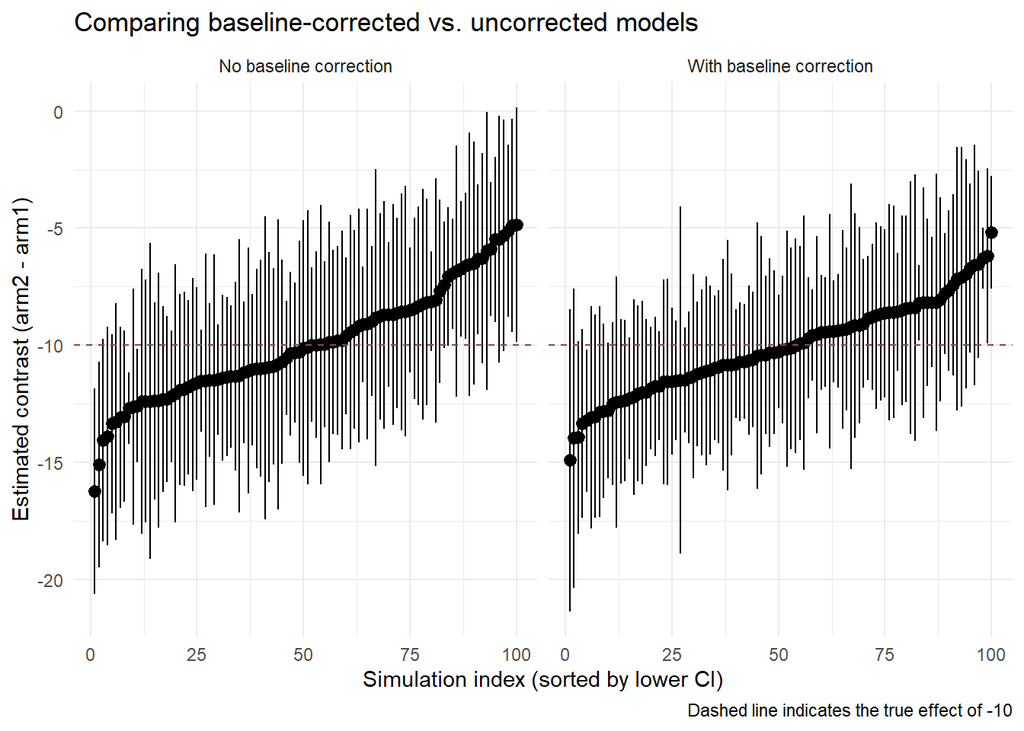

```r
# Compute 95% CI
res_baseline <- res_baseline %>%
  mutate(ci_low = estimate - 1.96 * SE,
         ci_upp = estimate + 1.96 * SE)

# Sort within each model by ci_low just to get a nice left-to-right ordering
res_baseline <- res_baseline %>%
  group_by(model) %>%
  arrange(estimate, .by_group = TRUE) %>%
  mutate(id = row_number()) %>%
  ungroup()

fig_3 <-
  # Plot
  ggplot(res_baseline, aes(x = id, y = estimate, ymin = ci_low, ymax = ci_upp)) +
    geom_pointrange() +
    facet_wrap(~ model, scales = "free_x") +
    # The true effect is +10 (arm2 - arm1)
    geom_hline(yintercept = -10, linetype = "dashed", color = "salmon4") +
    theme_minimal() +
    labs(
      x = "Simulation index (sorted by lower CI)",
      y = "Estimated contrast (arm2 - arm1)",
      title = "Comparing baseline-corrected vs. uncorrected models",
      caption = "Dashed line indicates the true effect of -10"
    )

fig_3
```

## Crazy idea: lets put the baseline on a spline

```r
set.seed(999)
n_sim <- 100

res_baseline <- data.frame()

pb <- txtProgressBar(min = 0, max = n_sim, style = 3)
```

```
##   |                                                                              |                                                                      |   0%
```

```r
for (i in 1:n_sim) {
  # Simulate the data
  dat <- sim_baseline_study(n_g = 5, eff = 10, eff_corr = 0.3, sd = 3)

  # Fit model with baseline correction
  mod_bc <- lm(y_after ~ arm + y_before, data = dat)
  tmp_bc <- emmeans(mod_bc, ~ arm) %>%
    contrast("pairwise") %>%
    as.data.frame()
  tmp_bc$model <- "With baseline correction"
  tmp_bc$rep   <- i

  # Fit model without baseline correction
  mod_bcsp <- lm(y_after ~ arm + ns( y_before, df = 2), data = dat)
  tmp_bcsp <- emmeans(mod_bcsp, ~ arm) %>%
    contrast("pairwise") %>%
    as.data.frame()
  tmp_bcsp$model <- "SPLINE baseline correction"
  tmp_bcsp$rep   <- i

  # Combine
  res_baseline <- rbind(res_baseline, tmp_bc, tmp_bcsp)

  setTxtProgressBar(pb, i)
}
```

```
##   |                                                                              |=                                                                     |   1%  |                                                                              |=                                                        …
```

```r
close(pb)
```

```r
# Compute 95% CI
res_baseline <- res_baseline %>%
  mutate(ci_low = estimate - 1.96 * SE,
         ci_upp = estimate + 1.96 * SE)

# Sort within each model by ci_low just to get a nice left-to-right ordering
res_baseline <- res_baseline %>%
  group_by(model) %>%
  arrange(estimate, .by_group = TRUE) %>%
  mutate(id = row_number()) %>%
  ungroup()
```

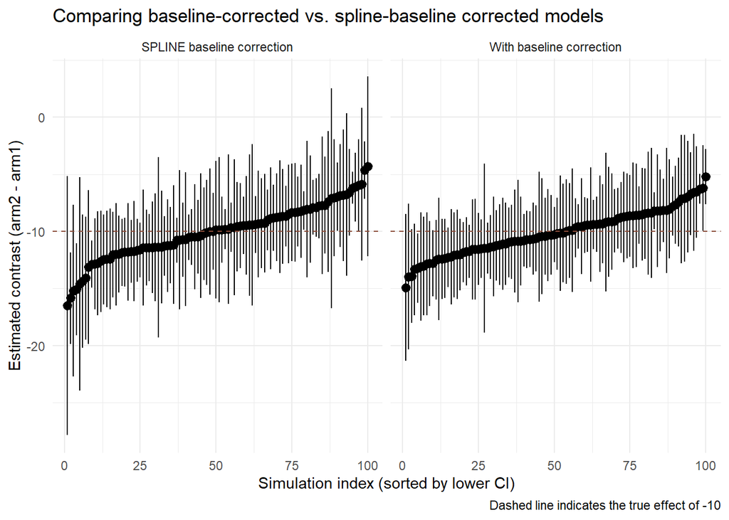

```r
fig_4 <-
  # Plot
  ggplot(res_baseline, aes(x = id, y = estimate, ymin = ci_low, ymax = ci_upp)) +
  geom_pointrange() +
  facet_wrap(~ model, scales = "free_x") +
  # The true effect is +10 (arm2 - arm1)
  geom_hline(yintercept = -10, linetype = "dashed", color = "salmon4") +
  theme_minimal() +
  labs(
    x = "Simulation index (sorted by lower CI)",
    y = "Estimated contrast (arm2 - arm1)",
    title = "Comparing baseline-corrected vs. spline-baseline corrected models",
    caption = "Dashed line indicates the true effect of -10"
  )

fig_4
```

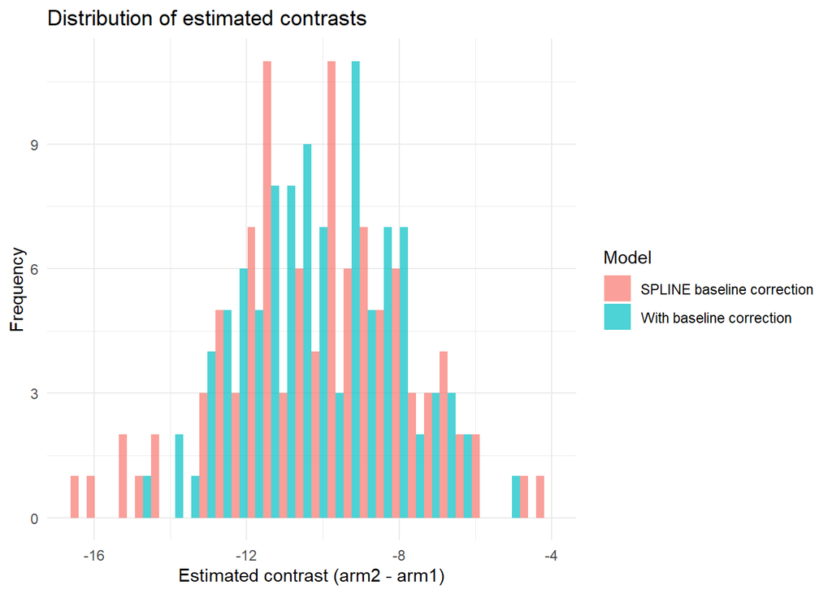

```r
fig_5 <-
  # plot estimates histogram per simulation
  res_baseline %>%
    ggplot(aes(x = estimate, fill = model)) +
    geom_histogram(bins = 30, position = "dodge", alpha = 0.7) +
    theme_minimal() +
    labs(
      x = "Estimated contrast (arm2 - arm1)",
      y = "Frequency",
      fill = "Model",
      title = "Distribution of estimated contrasts"
    )

fig_5
```